# 36-315 Homework 06, Fall 2019

Your Name Here

10/9/2019

## Problem 1

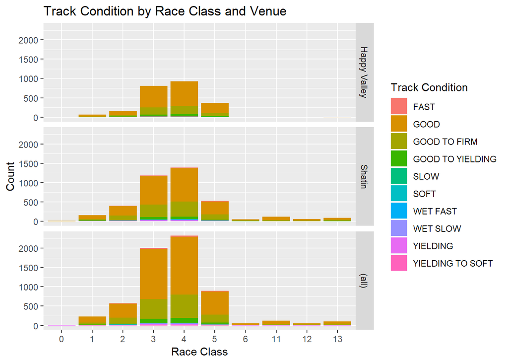

```r
library(tidyverse)
library(lubridate)

#  Read in data
path <- paste("https://raw.githubusercontent.com/mateyneykov/",
              "315_code_data/master/data/runs.csv", sep = "")
runs <- read_csv(path)
path <- paste("https://raw.githubusercontent.com/mateyneykov/",
              "315_code_data/master/data/races.csv", sep = "")
races <- read_csv(path)

# add some elementary dates and turn some vars to factors
races <- races %>% mutate(my_date = as.Date(date, format = "%Y-%m%-d"),
                          day = weekdays(my_date),
                          month = month(my_date),
                          weekend = ifelse(day %in% c("Saturday", "Sunday"),
                                           "Weekend", "Weekday"),
                          surface = factor(surface),
                          race_class = factor(race_class))

races %>%
  mutate(venue = fct_recode(venue, "Happy Valley" = "HV", "Shatin" = "ST")) %>%
  ggplot(aes(x = race_class, fill = going)) +
  geom_bar() +
  facet_grid(venue ~ ., margins = T) +
  labs(x = "Race Class", y = "Count",
       title = "Track Condition by Race Class and Venue",
       fill = "Track Condition")
```

1. Looking at the “all” facet, it looks like race class can be broken up into two sections of data. The left section is approximately symmetric and bell-shaped, and it appears to be centered around 3. The other cluster is approximately uniform; its frequencies are much smaller. Its also interesting that there are about five race classes that never appear in the data set.
2. In almost every race class, the mode track condition is “good.” Very few tracks are yielding or slow. The next most frequent track condition in the data set is good to firm. This makes sense since we would expect that the races would be held on tracks that are well kept.
3. Race class: For Shatin, there are also two clusters of race classes; again, the left cluster is bell-shaped and approximately symmetric, but the right cluster is much closer to a uniform distribution. The left cluster still seems to be centered around 3. Again, there are many race classes that do not occur at Shatin. Interestingly, Happy Valley only has race classes between 1 and 5. Within this range, the distribution of race classes is approximately symmetric and bell-shaped. Track condition: The track conditions at Happy Valley are only one of the following: good, good to firm, or good to yielding. The most frequently occuring race condition is “good.” Alternatively, Shatin has some races in conditions that are less favorable. Some, though few, races are held in conditions classified as “yielding.” However, most of the races are held in what are classified as “good” conditions.
4. Because I was originally interested in the distribution of race classes, I wanted to make a bar chart of the frequency of race classes. Then, because I was interested in the conditional distribution of track conditions given race class, I decided to fill my bars by track condition. Finally, to compare the marginal and conditional distributions in parts a and b across venues, I decided to facet by venue. I needed to set “margins = T” in facet_grid so that I could still see the marginal distribution of race classes even after faceting.

## Problem 2

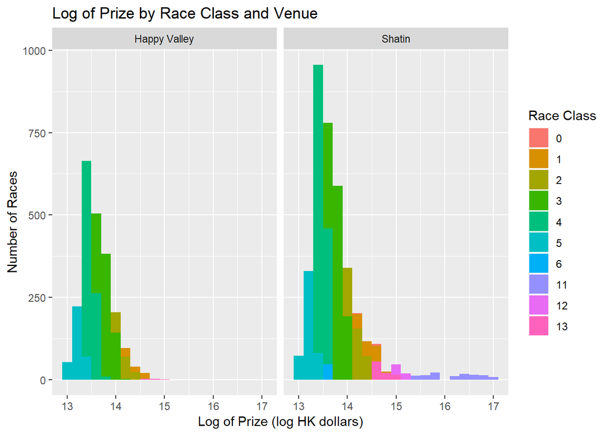

```r
# remove NA observations based on prize, but ggplot will remove it anyways
# races <- nrow(races[!is.na(races$prize),])

races %>%
  mutate(venue = fct_recode(venue, "Happy Valley" = "HV", "Shatin" = "ST")) %>%
  ggplot(aes(x = log(prize), fill = factor(race_class))) +
  geom_histogram(na.rm = TRUE, binwidth = .2) +
  facet_grid(.~venue) +
  labs(x = "Log of Prize (log HK dollars)", y = "Number of Races",
       fill = "Race Class", title = "Log of Prize by Race Class and Venue")
```

1. The distribution of log of the prize of the race is unimodal and slightly skewed right. The peak is roughly at 13.5 (log HK dollars), with range of around 13 to 15 (log HK dollars). There is an outlier on the right tail of the distribution.
2. From the histogram above, we can see that the distribution of log of price changes depending on the race class. Each have a different mode and range, with a smaller range for each race class. Class 5 races appear to yield the lowest prize while class 11 yields the highest. A possible ordering for the race classes by the amount of prize could be: 5, 4, 6, 3, 2, 1, 0, 13, 12, 11.
3. Comparing the two facets of venue, we can see that the shape of the distribution stays mostly similar: unimodal bell-shaped, with mode around 13.5 (log HK dollars). Also, both distributions are right skewed but while the distribution for Happy Valley is mildly skewed, we can see that the distribution for Shatin is more heavily right skewed with a more fat right tail as in the overall distribion. There are more number of races with higher log of prize for Shatin, so we can conlcude that Shatin venue gives higher prizes than the other one.
4. *Depends on individual.*

Example from student: I chose to use a stacked histogram facetted on venue because I wanted to show the marginal distribution of the log of prize on the x-axis, and it is a continuous variable, so I chose to use a histogram. The stacked part was chosen because I wanted to show the conditional distribution of race class given the prize, and I felt it was easier to show this with a histogram rather than a density plot. I facetted on venue to show how these distributions differed at the different venues.

## Problem 3

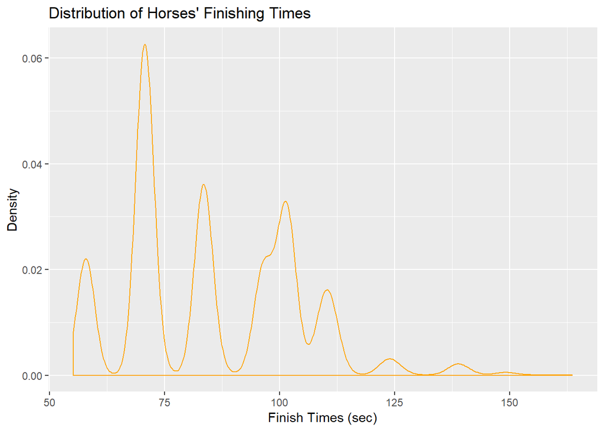

```r
ggplot(runs, aes(x = finish_time)) +
  geom_density(color = "orange") +
  labs(x = "Finish Times (sec)",
       y = "Density",
       title = "Distribution of Horses' Finishing Times")
```

```r
#This solution is also accepted.
alternative_plot <- ggplot(runs, aes(x = finish_time)) +
  geom_histogram(bins = 100, fill = "orange") +
  labs(x = "Finish Times (sec)",
       y = "Run Counts",
       title = "Distribution of Horses' Finishing Times")
```

1. Finish times are spread across a range between 55.16 and 163.58 seconds, with an average of 85.32. The distribution is multimodal and one interesting feature is that each cluster in distribution looks normal with a slight right skew. A careful consideration could reveal that the density has around 9 modes. This is somewhat intuitive since the lengths of the courses are different – there are 9 unique `distance` values in the `races` data set.

```r
# this code assumes that you have read the races.csv and runs.csv with read_csv
# and saved them in tables races and runs respectively

# uncomment to use the code
races_runs <- left_join(runs, races, by = c("race_id" = "race_id"))
```

2. The method called `left_join` merges two dataframes into one large data frame called `races_runs` on `race_id`. The new data frame has the same number of rows as `runs`. It has 74 columns, which is the sum of number of columns of each data frame minus 1 (`race_id` is present in both data sets). Fundamentally, it adds information about the race contained in the `races` table such as `distances` for each run looking at the `race_id`.

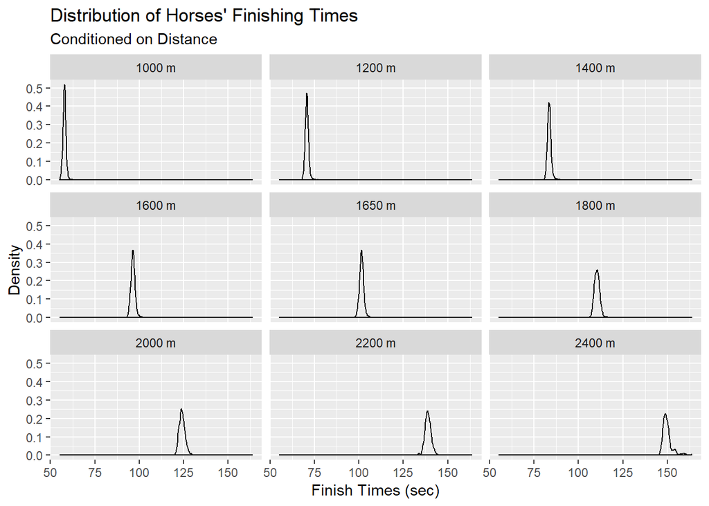

```r
races_runs %>%
  mutate(distance = fct_recode(as.character(distance), "1000 m" = "1000",
                               "1200 m" = "1200", "1400 m" = "1400",
                               "1600 m" = "1600", "1650 m" = "1650",
                               "1800 m" = "1800", "2000 m" = "2000",
                               "2200 m" = "2200", "2400 m" = "2400")) %>%
  ggplot(aes(x = finish_time)) +
  geom_density(alpha = 0.7) +
  facet_wrap(distance ~ .) +
  labs(x = "Finish Times (sec)",
       y = "Density",
       title = "Distribution of Horses' Finishing Times",
       subtitle = "Conditioned on Distance")
```

```r
alternative_solution_c <- ggplot(races_runs, aes(x = finish_time)) +
  geom_histogram(bins = 50, aes(fill = factor(distance)), alpha = 0.7) +
  labs(x = "Finish Times (sec)",
       y = "Run Counts",
       fill = "Distance (metres)",
       title = "Distribution of Horses' Finishing Times",
       subtitle = "Conditioned on Distance")

#This is given partial credit
alternative2 <- ggplot(races_runs, aes(x = factor(distance), y = finish_time)) +
  geom_boxplot() +
  labs(title = "Distribution of Finish Times Given Distance of Race",
       x = "Distance of Race (m)", y = "Finish Time (sec)")
```

3. Conditioning on the distance validated our claims in the previous part and revealed a unimodal distribution within most distance groups. As the distance increases, the mean of the distribution of the finish time also increases.
4. Since finishing time is a continuous variable, we use a density plot to display its distribution. (A histogram with sufficiently small bin widths is also suitable.) To see the distribution of the finishing times across runs, we used a density plot faceted on distance. This is a good idea because finishing time is a continuous variable and we want to compare distributions across 9 categories. For the second plot, filling based on the factorized distance is also an option, but for a more summarized view, we prefered faceting.

## Problem 4

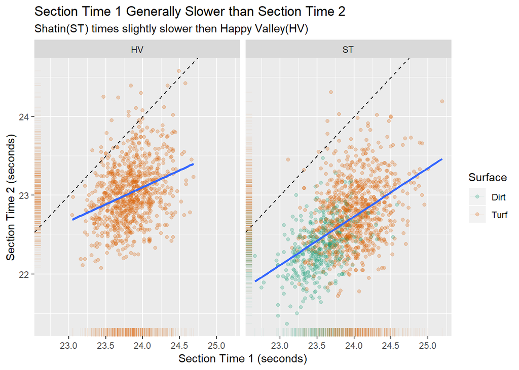

```r
races_1200 <- races[which(races$distance == 1200), ]
races_1200$surface <- ifelse(races_1200$surface == 0, "Turf", "Dirt")
ggplot(races_1200, aes(x = sec_time1, y = sec_time2)) +
  geom_point(aes(col = as.factor(surface)), alpha = 0.25) +
  geom_abline(slope = 1, intercept = 0, color = "black", linetype = "dashed") +
  geom_rug(aes(x = sec_time1, y = sec_time2, color = as.factor(surface)),
           alpha = 0.05) +
  geom_smooth(method = "lm", se = FALSE) +
  labs(
    title = "Section Time 1 Generally Slower than Section Time 2",
    subtitle =
    "Shatin(ST) times slightly slower then Happy Valley(HV)",
    x = "Section Time 1 (seconds)",
    y = "Section Time 2 (seconds)",
    col = "Surface"
  ) +
  facet_grid(~venue) +
  scale_color_brewer(palette = "Dark2")
```

1. We see almost all points on the above plot fall below the line $y = x$ (in black), indicating the time taken by the leader of the race to reach the end of the first sectional point is almost always larger than the time taken to reach the end of the second. The positive slope of the regression line (in blue) indicates horses that have relatively faster times to the first sectional point also have relatively faster times to the second sectional point.
2. The horses that race on the dirt surface at Shatin generally have shorter times to both sectional points, indicating that the dirt surface is faster than the turf surface.
3. It appears that section times on turf are quite similar to each other between the two venues. Overall, the mean section time would be faster at Shatin because of the races that took place on dirt.
4. Scatterplot is the most sensible way to compare these two related, continuous variables. The line at $y=x$ clearly shows how most of the horses have slower times to sectional 1, as they lie in the region $x>y$. The linear trend line shows a generally positive relationship between the two variables; fast horses continue to be fast and slow horses continue to be slow. The rug plot makes visualizing the individual distributions of each variable easier, and helps with comparison across venues. Coloring the points by surface type clearly shows the distribution of times between the different surfaces. Facetting by location makes comparing the distributions of times across the location easy. Finally, the palette Dark2 was chosen for color-blind safety and clear contrast.

## Problem 5

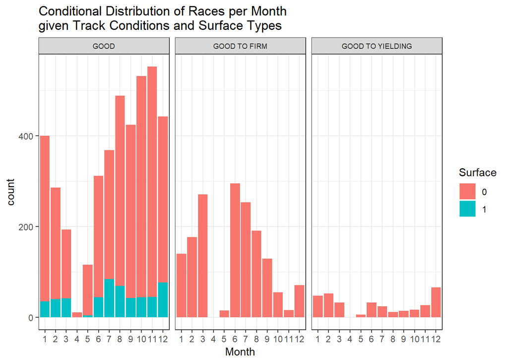

```r
ggplot(data = races %>%
         filter(going %in% c("GOOD",
                             "GOOD TO FIRM",
                             "GOOD TO YIELDING"))) +
  geom_bar(aes(x = factor(month), fill = surface)) +
  facet_grid( ~ going, scale = "free_y") +
  labs(title = paste("Conditional Distribution of Races per Month",
                     "\ngiven Track Conditions and Surface Types"),
       x = "Month",
       fill = "Surface") + theme_bw() +
  theme(strip.text = element_text(size = 7))
```

1. One interesting observation is that there are very few races in April and May. There seems to be consistant distributions from January through March.
2. Distribution of the races that were on dirt(1) surface seems to be highest on July and December. Most of the races were on turf(0) surface regardless of the month.
3. We can definitely see that all of the races that had track condition of “Good to Firm” or “Good to Yielding” were on turf(0) surfaces. The races that were on dirt(1) space all had the track condition of “Good”. This may suggest that dirt surface tend to stay consistent throughout the race. We can see that races with track condition “Good to Yielding” have low overall proportion. The distribution of track conditions over months suggest more races with track condition being “Good to Firm” in the summer seasons compared to winter seasons. The number of races with “Good to Yielding” track conditions seems to rise during the winter season compared to other months.
4. I used stacked histogram of races, colored based on surface type, and facetted on track conditions. The histogram will be useful in observing the distribution over different months and different color should let the audience differentiate the different behaviors for each surface. Facetting will allow display of different distribution for each track condition type.

## Problem 6

1. Using the winning odds for a horse at the start of the race, create a discretized variable which takes values 1 when the winning odds are between (0,20], 2 when the winning odds are (20, 70] and 3 when the winning odds are above 70.

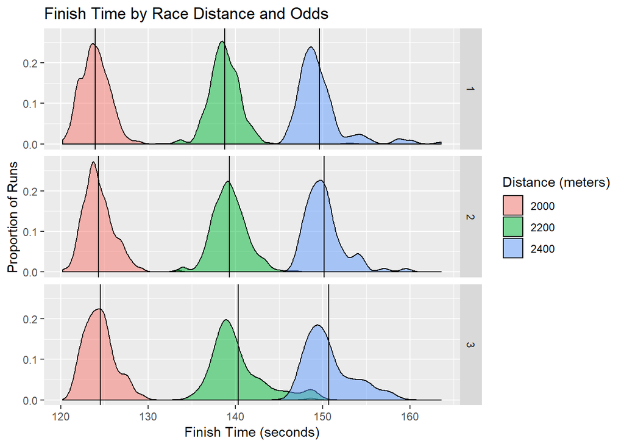

```r
races_subset <- races_runs[races_runs$distance %in% c(2000, 2200, 2400), ] %>%
                  mutate(winning_odds = cut(win_odds, c(0, 20, 70, Inf),
                                            labels = c("1", "2", "3")))
races_mean <- races_subset %>%
  group_by(distance, winning_odds) %>%
  summarise(mean=mean(finish_time))

ggplot(races_subset, aes(x = finish_time, fill = factor(distance))) +
  geom_density(alpha = 0.5) +
  geom_vline(data = races_mean,
             aes(xintercept = mean, group = factor(distance))) +
  facet_grid(winning_odds ~ .) +
  labs(x = "Finish Time (seconds)", y = "Proportion of Runs",
       fill = "Distance (meters)",
       color = "Distance (meters)",
       title = "Finish Time by Race Distance and Odds")
```

2. We are interested in whether the finishing time is faster when the variable you created in (a) is 1 compared to when this variable is 2 or 3. Present a graph that compares the finishing time within the levels of the variable created in (a). The finishing time is also related to the distance of the race, so do not forget to also take this into account. Comment on all interesting results form this graph. The finishing time appear roughly consistent accross all odds categories; the average finishing time for odds 1 is only slightly lower than odds 2 or 3. For each race distnace, the finishing time in seconds are fairly similar across all winning odd categoires. For 2000m race, the range of the finishing times is between 120 and 130 seconds for winning odds 1, 2, and 3. For the 2200m race, the finishing time ranges between 135 and 145 seconds for all winning odds, with winning odd 3 having a slightly more right skewness. Last, for the 2400 m race, the finishing time is in the interval 145 and 155 seconds for all winning odds 1,2, and 3.
3. *depends on individual*

student example: I chose to use a density plot so that the distribution of finishing time given each winning odds category would be equally shown with respect to area, and because finishing time is a continuous variable to the second decimal point. I filled the density plots by race length to compare how the densities were at different lengths, and used an alpha = 0.5 to show the overlaps. And I facetted on the new winning odds variable to show the differences in the distributions amongst these three categories.

## Problem 7

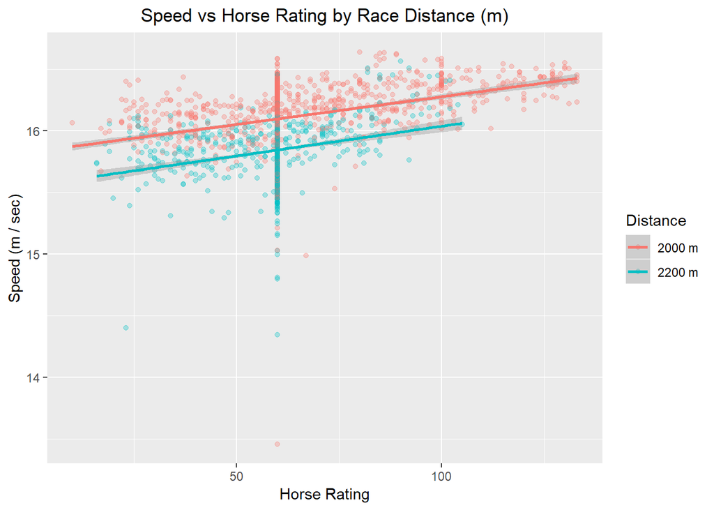

```r
races_runs <- races_runs %>% mutate(speed = distance / finish_time)

races_runs %>% filter(distance %in% c(2000, 2200)) %>%
  mutate(distance = fct_recode(factor(distance), "2000 m" = "2000",
                               "2200 m" = "2200")) %>%
  ggplot(aes(x = horse_rating, y = speed, color = distance)) +
  geom_point(alpha = 0.3) +
  geom_smooth(method = "lm") +
  labs(x = "Horse Rating",
       y = "Speed (m / sec)",
       color = "Distance",
       title = "Speed vs Horse Rating by Race Distance (m)") +
  theme(plot.title = element_text(hjust = 0.5))
```

1. Average speed is `distance / finish_time`, as constructed above.
2. Horse rating and speed seem to have a positive linear relationship with each other. This means that as horse rating increases, speed tends to be higher. However, we can see that the speeds for the two different race distances are different. The speed of horses in 2000 m races is generally higher than the speed of horses in 2200 m races.
3. From observing the graph, we can see that two linear regressions display similar slopes. This means that effect of horse rating on speed is similar for both distances. However, the regression lines clearly have different intercepts. Since the two lines do not lie in each other’s confidence intervals, we should not use the same model for predicting speed for two different distances.
4. A scatterplot is a good choice to show the relationship between two quantitative variables. We use color to differentiate between different race distances. One alternative is to facet on distance instead of coloring them. We display the regression line to visualize the trend more clearly.